# Matthew Bierman, Project 2

# Dataset #1: House Sales in King County, USA

Link to dataset on Kaggle: https://www.kaggle.com/harlfoxem/housesalesprediction

### Install Required Libraries

```r
library(caret)
```

```r
library(corrplot)
library(e1071)
library(dplyr)
library(tree)
library(neuralnet)
```

### Import Datasets

```r
houseData <- read.csv(file = "kc_house_data.csv", header = TRUE, sep = ",")
```

### Data Cleaning

```r
# removed id, lat, long
houseData <- houseData[, -c(1, 18, 19)]

# replaced sqft_living and sqft_lot with sqft_living15 and sqft_lot15 (respectively) since values are more recent
houseData$sqft_living <- houseData$sqft_living15
houseData$sqft_lot <- houseData$sqft_lot15
houseData <- houseData[, -c(17, 18)]

# yr_renovated will mess up Linear Regression with 0's as no renovation, replace with 1 = renovated, 0 = not renovated
houseData$is_renovated <- ifelse(houseData$yr_renovated == 0, 0, 1)

# replace date with year and month
houseData$year <- as.integer(substr(houseData$date, 0, 4))
houseData$month <- as.integer(substr(houseData$date, 5, 6))
houseData <- houseData[, -c(1)]

# add years_since_renovation column
houseData$years_since_renovation <- ifelse(houseData$yr_renovated == 0, abs(houseData$year - houseData$yr_built), abs(houseData$year - houseData$yr_renovated))
houseData <- houseData[, -c(14)]

str(houseData)
```

```
## 'data.frame':    21613 obs. of  18 variables:
##  $ price                 : num  221900 538000 180000 604000 510000 ...
##  $ bedrooms              : int  3 3 2 4 3 4 3 3 3 3 ...
##  $ bathrooms             : num  1 2.25 1 3 2 4.5 2.25 1.5 1 2.5 ...
##  $ sqft_living           : int  1340 1690 2720 1360 1800 4760 2238 1650 1780 2390 ...
##  $ sqft_lot              : int  5650 7639 8062 5000 7503 101930 6819 9711 8113 7570 ...
##  $ floors                : num  1 2 1 1 1 1 2 1 1 2 ...
##  $ waterfront            : int  0 0 0 0 0 0 0 0 0 0 ...
##  $ view                  : int  0 0 0 0 0 0 0 0 0 0 ...
##  $ condition             : int  3 3 3 5 3 3 3 3 3 3 ...
##  $ grade                 : int  7 7 6 7 8 11 7 7 7 7 ...
##  $ sqft_above            : int  1180 2170 770 1050 1680 3890 1715 1060 1050 1890 ...
##  $ sqft_basement         : int  0 400 0 910 0 1530 0 0 730 0 ...
##  $ yr_built              : int  1955 1951 1933 1965 1987 2001 1995 1963 1960 2003 ...
##  $ zipcode               : int  98178 98125 98028 98136 98074 98053 98003 98198 98146 98038 ...
##  $ is_renovated          : num  0 1 0 0 0 0 0 0 0 0 ...
##  $ year                  : int  2014 2014 2015 2014 2015 2014 2014 2015 2015 2015 ...
##  $ month                 : int  10 12 2 12 2 5 6 1 4 3 ...
##  $ years_since_renovation: int  59 23 82 49 28 13 19 52 55 12 ...
```

```r
summary(houseData)
```

```
##      price            bedrooms        bathrooms      sqft_living
##  Min.   :  75000   Min.   : 0.000   Min.   :0.000   Min.   : 399
##  1st Qu.: 321950   1st Qu.: 3.000   1st Qu.:1.750   1st Qu.:1490
##  Median : 450000   Median : 3.000   Median :2.250   Median :1840
##  Mean   : 540088   Mean   : 3.371   Mean   :2.115   Mean   :1987
##  3rd Qu.: 645000   3rd Qu.: 4.000   3rd Qu.:2.500   3rd Qu.:2360
##  Max.   :7700000   Max.   :33.000   Max.   :8.000   Max.   :6210
##     sqft_lot          floors        waterfront            view
##  Min.   :   651   Min.   :1.000   Min.   :0.000000   Min.   :0.0000
##  1st Qu.:  5100   1st Qu.:1.000   1st Qu.:0.000000   1st Qu.:0.0000
##  Median :  7620   Median :1.500   Median :0.000000   Median :0.0000
##  Mean   : 12768   Mean   :1.494   Mean   :0.007542   Mean   :0.2343
##  3rd Qu.: 10083   3rd Qu.:2.000   3rd Qu.:0.000000   3rd Qu.:0.0000
##  Max.   :871200   Max.   :3.500   Max.   :1.000000   Max.   :4.0000
##    condition         grade          sqft_above   sqft_basement
##  Min.   :1.000   Min.   : 1.000   Min.   : 290   Min.   :   0.0
##  1st Qu.:3.000   1st Qu.: 7.000   1st Qu.:1190   1st Qu.:   0.0
##  Median :3.000   Median : 7.000   Median :1560   Median :   0.0
##  Mean   :3.409   Mean   : 7.657   Mean   :1788   Mean   : 291.5
##  3rd Qu.:4.000   3rd Qu.: 8.000   3rd Qu.:2210   3rd Qu.: 560.0
##  Max.   :5.000   Max.   :13.000   Max.   :9410   Max.   :4820.0
##     yr_built       zipcode       is_renovated          year
##  Min.   :1900   Min.   :98001   Min.   :0.00000   Min.   :2014
##  1st Qu.:1951   1st Qu.:98033   1st Qu.:0.00000   1st Qu.:2014
##  Median :1975   Median :98065   Median :0.00000   Median :2014
##  Mean   :1971   Mean   :98078   Mean   :0.04229   Mean   :2014
##  3rd Qu.:1997   3rd Qu.:98118   3rd Qu.:0.00000   3rd Qu.:2015
##  Max.   :2015   Max.   :98199   Max.   :1.00000   Max.   :2015
##      month        years_since_renovation
##  Min.   : 1.000   Min.   :  0.00
##  1st Qu.: 4.000   1st Qu.: 15.00
##  Median : 6.000   Median : 37.00
##  Mean   : 6.574   Mean   : 40.94
##  3rd Qu.: 9.000   3rd Qu.: 60.00
##  Max.   :12.000   Max.   :115.00
```

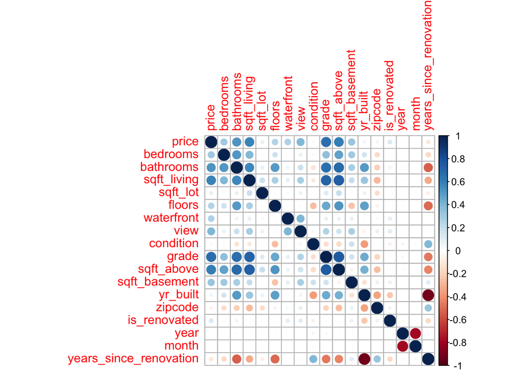

```r
# can't use pairs() b/c too many rows
corrplot(cor(houseData), method = "circle")
```

```r
# Split into testing and training
set.seed(4375)
i <- sample(1:nrow(houseData), nrow(houseData) * 0.75, replace = FALSE)
train <- houseData[i, ]
test <- houseData[-i, ]
```

### Linear Regression

```r
lm <- lm(price~., data = train)
summary(lm)
```

```
##
## Call:
## lm(formula = price ~ ., data = train)
##
## Residuals:
##      Min       1Q   Median       3Q      Max
## -1376002  -110027    -9113    92194  4233509
##
## Coefficients:
##                          Estimate Std. Error t value Pr(>|t|)
## (Intercept)            -6.426e+07  1.259e+07  -5.104 3.36e-07 ***
## bedrooms               -4.017e+04  2.363e+03 -16.996  < 2e-16 ***
## bathrooms               4.676e+04  4.132e+03  11.317  < 2e-16 ***
## sqft_living             1.770e+01  4.309e+00   4.108 4.00e-05 ***
## sqft_lot               -5.592e-01  6.362e-02  -8.789  < 2e-16 ***
## floors                  2.239e+04  4.507e+03   4.968 6.83e-07 ***
## waterfront              5.707e+05  2.134e+04  26.740  < 2e-16 ***
## view                    4.224e+04  2.656e+03  15.901  < 2e-16 ***
## condition               1.924e+04  3.001e+03   6.413 1.47e-10 ***
## grade                   1.233e+05  2.658e+03  46.390  < 2e-16 ***
## sqft_above              1.691e+02  4.568e+00  37.026  < 2e-16 ***
## sqft_basement           1.717e+02  5.505e+00  31.183  < 2e-16 ***
## yr_built               -2.765e+03  3.628e+02  -7.621 2.65e-14 ***
## zipcode                -3.137e+00  3.685e+01  -0.085  0.93217
## is_renovated            7.191e+04  2.247e+04   3.200  0.00137 **
## year                    3.431e+04  5.969e+03   5.748 9.21e-09 ***
## month                   1.467e+03  8.901e+02   1.648  0.09933 .
## years_since_renovation  8.372e+02  3.687e+02   2.271  0.02319 *
## ---
## Signif. codes:  0 '***' 0.001 '**' 0.01 '*' 0.05 '.' 0.1 ' ' 1
##
## Residual standard error: 220000 on 16191 degrees of freedom
## Multiple R-squared:  0.6548, Adjusted R-squared:  0.6544
## F-statistic:  1807 on 17 and 16191 DF,  p-value: < 2.2e-16
```

```r
# Accuracy
pred <- predict(lm, newdata = test)
paste("Accuracy: ", round(cor(pred, test$price) * 100, 2), "%", sep = "")
```

```
## [1] "Accuracy: 81.05%"
```

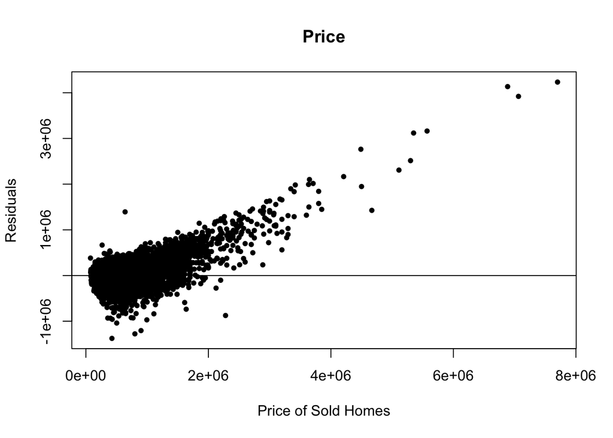

```r
plot(train$price, lm$residuals, ylab="Residuals", xlab="Price of Sold Homes", main="Price", pch = 20)
abline(0, 0)
```

### Remove Outliers

```r
# remove outliers
houseData <- houseData[(houseData$price < 4000000),]

# resample data
i <- sample(1:nrow(houseData), nrow(houseData) * 0.75, replace = FALSE)
train <- houseData[i, ]
test <- houseData[-i, ]
```

### Linear Regression – Without Outliers

```r
lm <- lm(price~. -zipcode -month -years_since_renovation -is_renovated, data = train)
summary(lm)
```

```
##
## Call:
## lm(formula = price ~ . - zipcode - month - years_since_renovation -
##     is_renovated, data = train)
##
## Residuals:
##      Min       1Q   Median       3Q      Max
## -1240799  -107145   -11505    87204  2141994
##
## Coefficients:
##                 Estimate Std. Error t value Pr(>|t|)
## (Intercept)   -4.680e+07  6.905e+06  -6.778 1.26e-11 ***
## bedrooms      -3.058e+04  2.189e+03 -13.972  < 2e-16 ***
## bathrooms      4.405e+04  3.765e+03  11.702  < 2e-16 ***
## sqft_living    4.420e+01  3.987e+00  11.088  < 2e-16 ***
## sqft_lot      -4.906e-01  6.290e-02  -7.799 6.64e-15 ***
## floors         3.901e+04  4.122e+03   9.465  < 2e-16 ***
## waterfront     5.217e+05  2.055e+04  25.391  < 2e-16 ***
## view           4.192e+04  2.458e+03  17.054  < 2e-16 ***
## condition      2.261e+04  2.695e+03   8.390  < 2e-16 ***
## grade          1.239e+05  2.470e+03  50.155  < 2e-16 ***
## sqft_above     1.266e+02  4.309e+00  29.380  < 2e-16 ***
## sqft_basement  1.426e+02  5.127e+00  27.823  < 2e-16 ***
## yr_built      -3.617e+03  7.346e+01 -49.232  < 2e-16 ***
## year           2.633e+04  3.428e+03   7.680 1.68e-14 ***
## ---
## Signif. codes:  0 '***' 0.001 '**' 0.01 '*' 0.05 '.' 0.1 ' ' 1
##
## Residual standard error: 204000 on 16186 degrees of freedom
## Multiple R-squared:  0.658,  Adjusted R-squared:  0.6577
## F-statistic:  2395 on 13 and 16186 DF,  p-value: < 2.2e-16
```

```r
# Accuracy
pred <- predict(lm, newdata = test)
paste("Accuracy: ", round(cor(pred, test$price) * 100, 2), "%", sep = "")
```

```
## [1] "Accuracy: 81.22%"
```

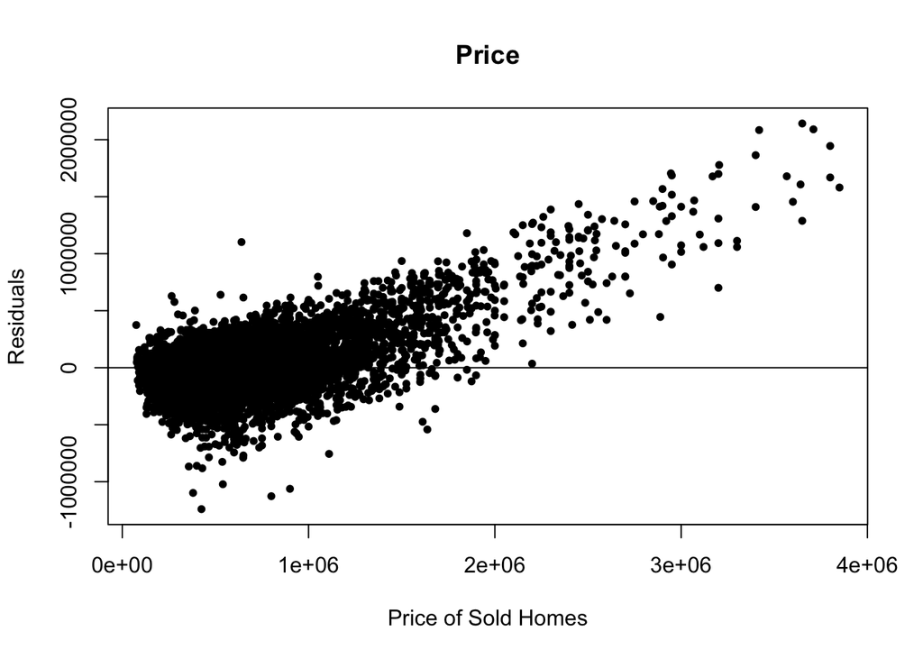

```r
plot(train$price, lm$residuals, ylab="Residuals", xlab="Price of Sold Homes", main="Price", pch = 20)
abline(0, 0)
```

### SVM – Linear

```r
svm <- svm(price ~ ., train, kernel = "linear")
pred <- predict(svm, test)

# Accuracy
paste("Accuracy: ", round(cor(pred, test$price) * 100, 2), "%", sep = "")
```

```
## [1] "Accuracy: 81.01%"
```

### SVM – Radial

```r
svm <- svm(price ~ ., train, kernel = "radial")
pred <- predict(svm, test)

# Accuracy
paste("Accuracy: ", round(cor(pred, test$price) * 100, 2), "%", sep = "")
```

```
## [1] "Accuracy: 85.98%"
```

### SVM – Polynomial

```r
svm <- svm(price ~ ., train, kernel = "polynomial")
pred <- predict(svm, test)

# Accuracy
paste("Accuracy: ", round(cor(pred, test$price) * 100, 2), "%", sep = "")
```

```
## [1] "Accuracy: 78.62%"
```

### Neural Networks

```r
scaledHouseData <- as.data.frame(scale(houseData, center = apply(houseData, 2, min), scale = apply(houseData, 2, max) - apply(houseData, 2, min)))

# resample data
i <- sample(1:nrow(scaledHouseData), nrow(scaledHouseData) * 0.75, replace = FALSE)
train <- scaledHouseData[i, ]
test <- scaledHouseData[-i, ]

n <- names(train)
f <- as.formula(paste("price ~", paste(n[!n %in% "price"], collapse = " + ")))
nn <- neuralnet(f, data = train, hidden = c(5,3), linear.output = T)

pred <- compute(nn, test[, -1])

pred <- pred$net.result * (max(houseData$price) - min(houseData$price)) + min(houseData$price)
scaledPrice <- (test$price) * (max(houseData$price) - min(houseData$price)) + min(houseData$price)

# Accuracy
paste("Accuracy: ", round(cor(pred, scaledPrice) * 100, 2), "%", sep = "")
```

```
## [1] "Accuracy: 72.88%"
```

### Conclusion

Since I used regression to predict house prices for this dataset, I used accuracy of correlation as my evaluation metrics for comparing Linear Regression, SVM, and Neural Networks. With Linear Regression, I had an accuracy of 81.05% with outliers and 81.22% without outliers. With SVM, I had an accuracy of 81.01% with a linear kernel, 85.98% with a radial kernel, and 78.62% with a polynomial kernel. With Neural Networks, I had an accuracy of 72.88%. I think SVM (with a radial kernel) performed best of the three algorithms because of the correlation graph, which showed clusters of high correlation in the top left, center left, and top center. My feature selection from looking at the different data types of the original dataset. I converted the time (which was a string) into numeric year and month variables, although the month variable wasn’t as helpful. I also created a years_since_renovation column because some homes were never renovated, and having a 0 in the renovation year column might throw off the Linear Regression model. Through my initial Linear Regression model, I saw the best features to remove were zipcode, month, years_since_renovation, and is_renovated. One surprising thing I learned from the data is that zipcode does not affect house prices. I was surprised by this because I imagined houses with high prices would be in the same area as other houses with high prices, and likewise with low priced homes.

# Dataset #2: French employment, salaries, population per town

Link to dataset on Kaggle: https://www.kaggle.com/etiennelq/french-employment-by-town

### Import Datasets

```r
townData <- read.csv(file = "base_etablissement_par_tranche_effectif.csv", header = TRUE, sep = ",")
salaryData <- read.csv(file = "net_salary_per_town_categories.csv", header = TRUE, sep = ",")
populationData <- read.csv(file = "populationCondensed.csv", header = TRUE, sep = ",")
```

### Data Cleaning

```r
# merge town and salary data
townData <- merge(townData, salaryData, by = c("CODGEO", "LIBGEO"), all = TRUE)

# remove libgeo column
townData <- townData[, -c(2, 6:14)]

# convert dep from factor to int
townData$DEP <- as.integer(townData$DEP)

# Here is the original code for creating populationCondensed.csv: 332.9MB -> 437KB
# group population data into only total number of people for each town
# populationData <- as.data.frame(populationData %>% group_by(CODGEO) %>% summarise(sum(NB)))
# write.csv(populationData, "populationCondensed.csv", row.names = FALSE)

townData <- merge(townData, populationData, by = c("CODGEO"), all = TRUE)

# rename new column from "sum.NB." to "population"
colnames(townData)[colnames(townData) == "sum.NB."] <- "population"

str(townData)
```

```
## 'data.frame':    36689 obs. of  29 variables:
##  $ CODGEO    : Factor w/ 36683 levels "01001","01002",..: 1 2 3 4 5 6 7 8 9 10 ...
##  $ REG       : int  82 82 82 82 82 82 82 82 82 82 ...
##  $ DEP       : int  1 1 1 1 1 1 1 1 1 1 ...
##  $ E14TST    : int  25 10 996 99 4 124 48 22 33 14 ...
##  $ SNHM14    : num  NA NA 13.7 NA NA 13.5 NA NA NA NA ...
##  $ SNHMC14   : num  NA NA 24.2 NA NA 22.1 NA NA NA NA ...
##  $ SNHMP14   : num  NA NA 15.5 NA NA 14.7 NA NA NA NA ...
##  $ SNHME14   : num  NA NA 10.3 NA NA 10.7 NA NA NA NA ...
##  $ SNHMO14   : num  NA NA 11.2 NA NA 11.4 NA NA NA NA ...
##  $ SNHMF14   : num  NA NA 11.6 NA NA 11.9 NA NA NA NA ...
##  $ SNHMFC14  : num  NA NA 19.1 NA NA 19 NA NA NA NA ...
##  $ SNHMFP14  : num  NA NA 13.2 NA NA 13.3 NA NA NA NA ...
##  $ SNHMFE14  : num  NA NA 10.1 NA NA 10.6 NA NA NA NA ...
##  $ SNHMFO14  : num  NA NA 9.6 NA NA 10 NA NA NA NA ...
##  $ SNHMH14   : num  NA NA 15 NA NA 14.7 NA NA NA NA ...
##  $ SNHMHC14  : num  NA NA 26.4 NA NA 23.3 NA NA NA NA ...
##  $ SNHMHP14  : num  NA NA 16.7 NA NA 15.8 NA NA NA NA ...
##  $ SNHMHE14  : num  NA NA 11 NA NA 11.3 NA NA NA NA ...
##  $ SNHMHO14  : num  NA NA 11.6 NA NA 11.7 NA NA NA NA ...
##  $ SNHM1814  : num  NA NA 10.5 NA NA 9.8 NA NA NA NA ...
##  $ SNHM2614  : num  NA NA 13.7 NA NA 13.8 NA NA NA NA ...
##  $ SNHM5014  : num  NA NA 16.1 NA NA 14.6 NA NA NA NA ...
##  $ SNHMF1814 : num  NA NA 9.7 NA NA 9.2 NA NA NA NA ...
##  $ SNHMF2614 : num  NA NA 11.8 NA NA 12.2 NA NA NA NA ...
##  $ SNHMF5014 : num  NA NA 12.5 NA NA 12.5 NA NA NA NA ...
##  $ SNHMH1814 : num  NA NA 11 NA NA 10.2 NA NA NA NA ...
##  $ SNHMH2614 : num  NA NA 14.9 NA NA 14.9 NA NA NA NA ...
##  $ SNHMH5014 : num  NA NA 18.6 NA NA 16.4 NA NA NA NA ...
##  $ population: int  765 227 13460 1595 84 2563 664 340 1100 396 ...
```

```r
# remove CODGEO
townData <- townData[, -1]

# remove all rows with NA
townData <- na.omit(townData)

# Split into testing and training
set.seed(4375)
i <- sample(1:nrow(townData), nrow(townData) * 0.75, replace = FALSE)
train <- townData[i, ]
test <- townData[-i, ]
```

### Linear Regression

```r
lm <- lm(E14TST~., data = train)
summary(lm)
```

```
##
## Call:
## lm(formula = E14TST ~ ., data = train)
##
## Residuals:
##    Min     1Q Median     3Q    Max
## -38329   -242    187    595  55051
##
## Coefficients:
##               Estimate Std. Error t value Pr(>|t|)
## (Intercept) -4.568e+03  1.140e+03  -4.007 6.28e-05 ***
## REG          3.060e+00  1.381e+00   2.216 0.026753 *
## DEP         -4.453e+00  1.358e+00  -3.280 0.001047 **
## SNHM14      -1.658e+03  6.487e+02  -2.556 0.010621 *
## SNHMC14     -2.770e+00  1.310e+02  -0.021 0.983130
## SNHMP14      8.073e+02  1.902e+02   4.243 2.25e-05 ***
## SNHME14     -4.779e+01  4.869e+02  -0.098 0.921828
## SNHMO14      1.754e+03  3.730e+02   4.703 2.66e-06 ***
## SNHMF14      2.567e+03  4.871e+02   5.270 1.44e-07 ***
## SNHMFC14     5.797e+01  4.794e+01   1.209 0.226638
## SNHMFP14    -2.826e+02  1.120e+02  -2.523 0.011685 *
## SNHMFE14     5.569e+02  3.599e+02   1.548 0.121774
## SNHMFO14     2.726e+01  6.822e+01   0.400 0.689458
## SNHMH14      1.650e+03  4.201e+02   3.929 8.69e-05 ***
## SNHMHC14     4.601e+01  8.885e+01   0.518 0.604589
## SNHMHP14    -4.048e+02  9.862e+01  -4.104 4.14e-05 ***
## SNHMHE14     2.292e+02  1.365e+02   1.680 0.093094 .
## SNHMHO14    -1.510e+03  3.140e+02  -4.810 1.56e-06 ***
## SNHM1814     2.225e+02  3.611e+02   0.616 0.537885
## SNHM2614    -1.040e+03  5.763e+02  -1.805 0.071135 .
## SNHM5014     4.478e+02  2.304e+02   1.943 0.052080 .
## SNHMF1814   -5.210e+02  1.648e+02  -3.161 0.001585 **
## SNHMF2614   -1.269e+03  3.519e+02  -3.605 0.000316 ***
## SNHMF5014   -9.171e+02  1.544e+02  -5.938 3.14e-09 ***
## SNHMH1814   -2.173e+02  2.250e+02  -0.965 0.334365
## SNHMH2614    2.975e+02  3.624e+02   0.821 0.411856
## SNHMH5014   -4.864e+02  1.287e+02  -3.778 0.000161 ***
## population   1.734e-01  8.116e-04 213.699  < 2e-16 ***
## ---
## Signif. codes:  0 '***' 0.001 '**' 0.01 '*' 0.05 '.' 0.1 ' ' 1
##
## Residual standard error: 1936 on 3797 degrees of freedom
## Multiple R-squared:  0.9266, Adjusted R-squared:  0.9261
## F-statistic:  1777 on 27 and 3797 DF,  p-value: < 2.2e-16
```

```r
# Accuracy
pred <- predict(lm, newdata = test)
paste("Accuracy: ", round(cor(pred, test$E14TST) * 100, 2), "%", sep = "")
```

```
## [1] "Accuracy: 97.37%"
```

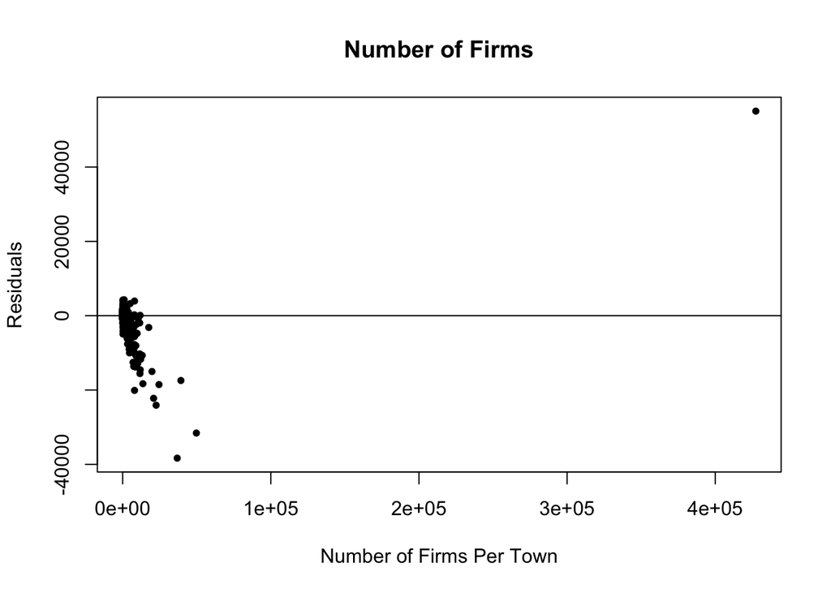

```r
plot(train$E14TST, lm$residuals, ylab="Residuals", xlab="Number of Firms Per Town", main="Number of Firms", pch = 20)
abline(0, 0)
```

### Remove Outliers

```r
# remove outliers
townData <- townData[(townData$E14TST < 15000),]

# resample data
i <- sample(1:nrow(townData), nrow(townData) * 0.75, replace = FALSE)
train <- townData[i, ]
test <- townData[-i, ]
```

### Linear Regression – Without Outliers

```r
lm <- lm(E14TST~REG + SNHMC14 + SNHMFC14 + SNHMHC14 + population, data = train)
summary(lm)
```

```
##
## Call:
## lm(formula = E14TST ~ REG + SNHMC14 + SNHMFC14 + SNHMHC14 + population,
##     data = train)
##
## Residuals:
##     Min      1Q  Median      3Q     Max
## -4091.6  -105.9    -9.6    78.9  5762.3
##
## Coefficients:
##               Estimate Std. Error t value Pr(>|t|)
## (Intercept) -6.430e+02  5.757e+01 -11.169   <2e-16 ***
## REG          3.022e+00  2.150e-01  14.053   <2e-16 ***
## SNHMC14     -1.829e+02  1.897e+01  -9.639   <2e-16 ***
## SNHMFC14     5.432e+01  6.086e+00   8.927   <2e-16 ***
## SNHMHC14     1.468e+02  1.334e+01  11.001   <2e-16 ***
## population   7.205e-02  4.242e-04 169.826   <2e-16 ***
## ---
## Signif. codes:  0 '***' 0.001 '**' 0.01 '*' 0.05 '.' 0.1 ' ' 1
##
## Residual standard error: 355.3 on 3810 degrees of freedom
## Multiple R-squared:  0.8903, Adjusted R-squared:  0.8902
## F-statistic:  6186 on 5 and 3810 DF,  p-value: < 2.2e-16
```

```r
# Accuracy
pred <- predict(lm, newdata = test)
paste("Accuracy: ", round(cor(pred, test$E14TST) * 100, 2), "%", sep = "")
```

```
## [1] "Accuracy: 95.61%"
```

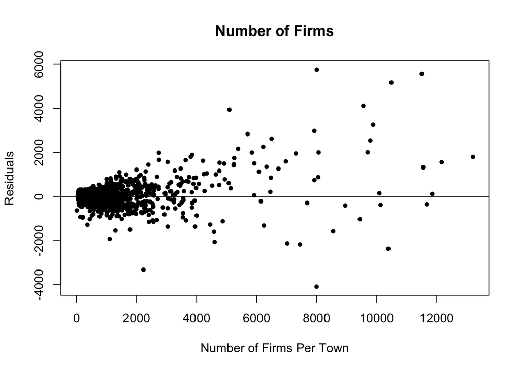

```r
plot(train$E14TST, lm$residuals, ylab="Residuals", xlab="Number of Firms Per Town", main="Number of Firms", pch = 20)
abline(0, 0)
```

```r
# 95.4%: (all)
# 95.68%: REG + SNHMC14 + SNHME14 + SNHMFC14 + SNHMFP14 + SNHMFE14 + SNHMHC14 + SNHMHE14 + SNHM5014 + SNHMH5014 + population
# 95.12%: population
```

### Linear Regression – For Comparison: Without Population Dataset

```r
lm <- lm(E14TST~.-population, data = train)
summary(lm)
```

```
##
## Call:
## lm(formula = E14TST ~ . - population, data = train)
##
## Residuals:
##     Min      1Q  Median      3Q     Max
## -2541.9  -380.6  -123.3   134.4 11119.6
##
## Coefficients:
##               Estimate Std. Error t value Pr(>|t|)
## (Intercept)   157.9467   581.8954   0.271 0.786071
## REG             1.4553     0.6894   2.111 0.034838 *
## DEP             2.0745     0.6698   3.097 0.001968 **
## SNHM14        182.6890   323.5593   0.565 0.572364
## SNHMC14      -262.1785    66.5373  -3.940 8.28e-05 ***
## SNHMP14      -465.7227    95.6925  -4.867 1.18e-06 ***
## SNHME14       515.8533   236.1952   2.184 0.029022 *
## SNHMO14     -1007.4301   183.7794  -5.482 4.49e-08 ***
## SNHMF14     -1129.2781   242.4682  -4.657 3.31e-06 ***
## SNHMFC14       51.8132    24.1634   2.144 0.032074 *
## SNHMFP14      239.8573    56.1320   4.273 1.98e-05 ***
## SNHMFE14     -721.4330   176.9595  -4.077 4.66e-05 ***
## SNHMFO14      -25.6003    34.2991  -0.746 0.455483
## SNHMH14      -443.3584   206.4535  -2.147 0.031817 *
## SNHMHC14      212.5389    44.9404   4.729 2.33e-06 ***
## SNHMHP14      251.0468    49.4581   5.076 4.04e-07 ***
## SNHMHE14     -280.4696    65.9305  -4.254 2.15e-05 ***
## SNHMHO14      884.9998   155.5230   5.690 1.36e-08 ***
## SNHM1814     -341.4451   180.6927  -1.890 0.058882 .
## SNHM2614      769.9959   291.2716   2.644 0.008238 **
## SNHM5014     -408.1818   113.6411  -3.592 0.000333 ***
## SNHMF1814     473.4392    82.4831   5.740 1.02e-08 ***
## SNHMF2614     652.8798   175.3861   3.723 0.000200 ***
## SNHMF5014     563.2894    76.0864   7.403 1.63e-13 ***
## SNHMH1814     266.2648   114.3213   2.329 0.019907 *
## SNHMH2614    -350.9793   182.2461  -1.926 0.054197 .
## SNHMH5014     348.6331    62.6006   5.569 2.74e-08 ***
## ---
## Signif. codes:  0 '***' 0.001 '**' 0.01 '*' 0.05 '.' 0.1 ' ' 1
##
## Residual standard error: 964 on 3789 degrees of freedom
## Multiple R-squared:  0.197,  Adjusted R-squared:  0.1915
## F-statistic: 35.76 on 26 and 3789 DF,  p-value: < 2.2e-16
```

```r
# Accuracy
pred <- predict(lm, newdata = test)
paste("Accuracy: ", round(cor(pred, test$E14TST) * 100, 2), "%", sep = "")
```

```
## [1] "Accuracy: 45.83%"
```

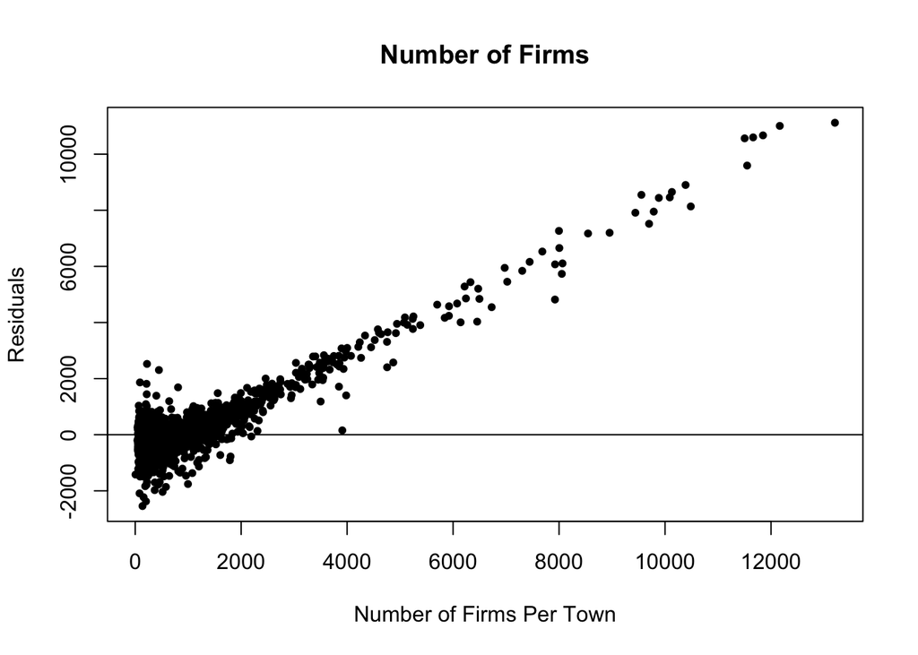

```r
plot(train$E14TST, lm$residuals, ylab="Residuals", xlab="Number of Firms Per Town", main="Number of Firms", pch = 20)
abline(0, 0)
```

### Decision Tree

```r
tree <- tree(E14TST~., data = train)

summary(tree)
```

```
##
## Regression tree:
## tree(formula = E14TST ~ ., data = train)
## Variables actually used in tree construction:
## [1] "population"
## Number of terminal nodes:  8
## Residual mean deviance:  138500 = 527600000 / 3808
## Distribution of residuals:
##     Min.  1st Qu.   Median     Mean  3rd Qu.     Max.
## -3080.00  -111.60   -41.63     0.00    76.95  6061.00
```

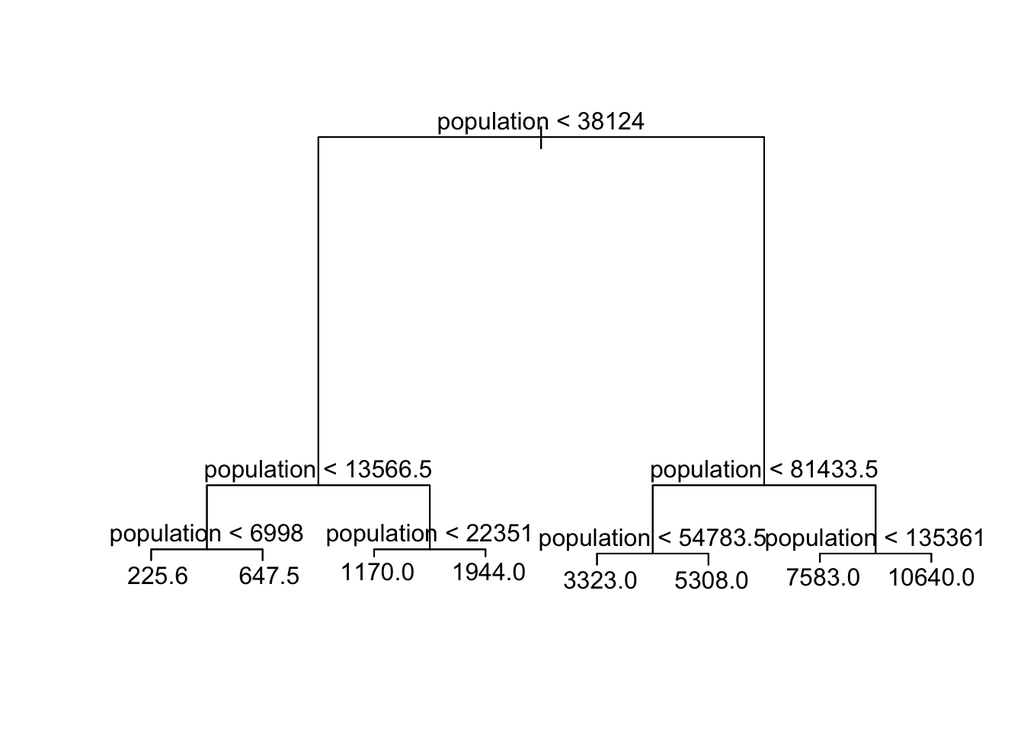

```r
plot(tree)
text(tree, pretty = 0)
```

```r
tree
```

```
## node), split, n, deviance, yval
##       * denotes terminal node
##
##  1) root 3816 4.385e+09   564.8
##    2) population < 38124 3690 8.743e+08   412.5
##      4) population < 13566.5 3332 1.883e+08   294.6
##        8) population < 6998 2787 5.294e+07   225.6 *
##        9) population > 6998 545 5.426e+07   647.5 *
##      5) population > 13566.5 358 2.088e+08  1510.0
##       10) population < 22351 201 5.223e+07  1170.0 *
##       11) population > 22351 157 1.038e+08  1944.0 *
##    3) population > 38124 126 9.188e+08  5025.0
##      6) population < 81433.5 98 2.590e+08  3951.0
##       12) population < 54783.5 67 6.918e+07  3323.0 *
##       13) population > 54783.5 31 1.063e+08  5308.0 *
##      7) population > 81433.5 28 1.512e+08  8784.0
##       14) population < 135361 17 6.320e+07  7583.0 *
##       15) population > 135361 11 2.568e+07 10640.0 *
```

```r
# Accuracy
pred <- predict(tree, newdata = test)
paste("Accuracy: ", round(cor(pred, test$E14TST) * 100, 2), "%", sep = "")
```

```
## [1] "Accuracy: 93.33%"
```

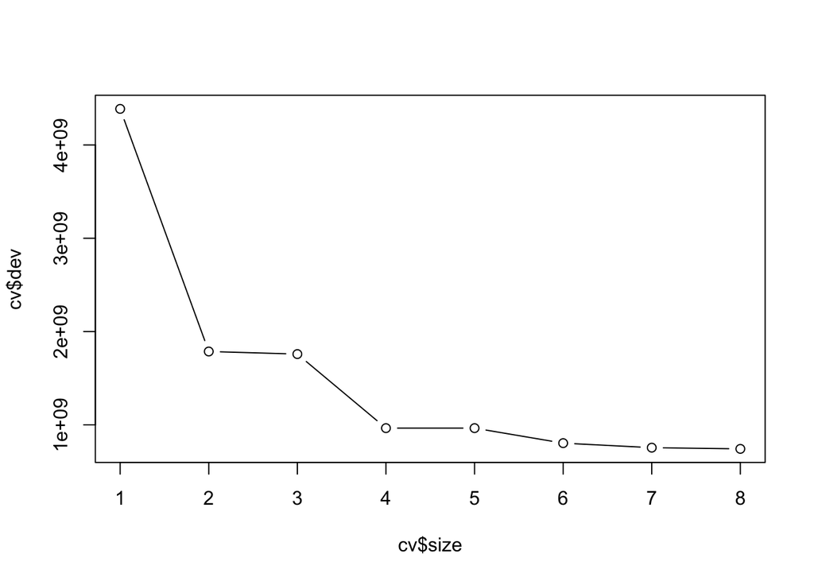

```r
# Cross Validation graph
cv = cv.tree(tree)
plot(cv$size, cv$dev, type = "b")
```

```r
# already at best size, no pruning needed
```

### kNN

```r
# Using k = 3
fit <- knnreg(train[, -3], train[, 3], k = 3)
pred <- predict(fit, test[, -3])
paste("Accuracy: ", round(cor(pred, test$E14TST) * 100, 2), "%", sep = "")
```

```
## [1] "Accuracy: 93.11%"
```

```r
# Using k = 5
fit <- knnreg(train[, -3], train[, 3], k = 5)
pred <- predict(fit, test[, -3])
paste("Accuracy: ", round(cor(pred, test$E14TST) * 100, 2), "%", sep = "")
```

```
## [1] "Accuracy: 94.48%"
```

```r
# Using k = 7
fit <- knnreg(train[, -3], train[, 3], k = 7)
pred <- predict(fit, test[, -3])
paste("Accuracy: ", round(cor(pred, test$E14TST) * 100, 2), "%", sep = "")
```

```
## [1] "Accuracy: 94.5%"
```

```r
# Using k = square root of the number of rows in the townData dataset
fit <- knnreg(train[, -3], train[, 3], k = sqrt(nrow(townData)))
pred <- predict(fit, test[, -3])
paste("Accuracy: ", round(cor(pred, test$E14TST) * 100, 2), "%", sep = "")
```

```
## [1] "Accuracy: 93.59%"
```

### Conclusion

Since I used regression to predict number of firms in a town for this dataset, I used accuracy of correlation as my evaluation metrics for comparing Linear Regression, Decision Trees, and kNN. With Linear Regression, I had an accuracy of 97.37% with outliers and 95.61% without outliers. With Decision Trees, I had an accuracy of 93.33%. With kNN, I had an accuracy of 93.11% for k = 3, 94.48% for k = 5, 94.5% for k = 7, and 93.59% for k = sqrt(nrow(townData)). I think Linear Regression performed best because town population was directly correlated to number of firms in the respective town. My feature selection included merging multiple datasets to find the best features in each while condensing the population file to take the sum of each town to get the total population for each town, condensing the population.csv file from 332.9MB to 437KB, making it much easier to work with. I was surprised to see that population had the only impact on the Decision Tree algorithm, but when using only population for Linear Regression, I got a lower accuracy than with all features.